# Analysis of the Data Science Job Market in the U.S.

Bethany Kuo

## Outline

- 1. Introduction
     - 1.1 Background
     - 1.2 Setup
- 1. Data Collection
     - 2.1 About the Data
     - 2.2 Loading the Data
     - 2.3 Data Wrangling
- 1. Data Exploration and Analysis
     - 3.1 Jobs
     - 3.2 Companies
     - 3.3 Sectors
- 1. Machine Learning
     - 3.1 Job Salary
     - 3.2 Company Rating
- 1. Conclusion

# 1. Introduction

## 1.1 Background

Data Science is a quickly growing field. According to the [Bureau of Labor Statistics](https://www.bls.gov/ooh/computer-and-information-technology/computer-and-information-research-scientists.htm), the field (computer and information research scientists) is expected to grow by 22% between 2020 and 2030, which is much faster than average.

The purpose of this tutorial is to examine the data science job market in the U.S. and gain insights about the kinds of jobs, companies, and sectors make up the job market, and what kinds of factors impact job salaries and company ratings.

## 1.2 Setup

- Folium: used for visualizing data on a map.
- Matplotlib: used for all other plots.
- Numpy: used for supporting data.
- Pandas: used for storing and processing data.
- Re: regular expression package used for cleaning data.
- Scikit-learn: used for training a predictive model from the data.
- Wordcloud: used for visualizing frequency of text.

```python
import folium
import matplotlib.pyplot as plt
import numpy as np
import pandas as pd
import re

from matplotlib.pyplot import figure
from sklearn.linear_model import LinearRegression
from sklearn.metrics import r2_score
from sklearn.model_selection import train_test_split
from sklearn.tree import DecisionTreeRegressor
from wordcloud import WordCloud
```

# 2. Data Collection

## 2.1 About the Data

The dataset used in this tutorial was downloaded from kaggle (https://www.kaggle.com/andrewmvd/data-scientist-jobs). The dataset includes 3909 data science job listings in 2020 scraped from Glassdoor, with 17 features such as job title, salary estimate, company name, location, etc. The set includes entries for jobs in the United States and the United Kingdom (but we will focus on the entries in the United States, which makes up a vast majority of the entries).

## 2.2 Loading the Data

The first step is to load the data. First, download [the CSV from kaggle](https://www.kaggle.com/andrewmvd/data-scientist-jobs) into the same directory as your code. Then, we load the CSV into a pandas dataframe for easy viewing and manipulation.

```python
jobs = pd.read_csv('DataScientist.csv')
jobs.head()
```

|  | Unnamed: 0 | index | Job Title | Salary Estimate | Job Description | Rating | Company Name | Location | Headquarters | Size | Founded | Type of ownership | Industry | Sector | Revenue | Competitors | Easy Apply |
| --- | --- | --- | --- | --- | --- | --- | --- | --- | --- | --- | --- | --- | --- | --- | --- | --- | --- |
| 0 | 0 | 0 | Senior Data Scientist | $111K-$181K (Glassdoor est.) | ABOUT HOPPER\n\nAt Hopper, we’re on a mission ... | 3.5 | Hopper\n3.5 | New York, NY | Montreal, Canada | 501 to 1000 employees | 2007 | Company - Private | Travel Agencies | Travel & Tourism | Unknown / Non-Applicable | -1 | -1 |
| 1 | 1 | 1 | Data Scientist, Product Analytics | $111K-$181K (Glassdoor est.) | At Noom, we use scientifically proven methods ... | 4.5 | Noom US\n4.5 | New York, NY | New York, NY | 1001 to 5000 employees | 2008 | Company - Private | Health, Beauty, & Fitness | Consumer Services | Unknown / Non-Applicable | -1 | -1 |
| 2 | 2 | 2 | Data Science Manager | $111K-$181K (Glassdoor est.) | Decode_M\n\nhttps://www.decode-m.com/\n\nData ... | -1.0 | Decode_M | New York, NY | New York, NY | 1 to 50 employees | -1 | Unknown | -1 | -1 | Unknown / Non-Applicable | -1 | True |
| 3 | 3 | 3 | Data Analyst | $111K-$181K (Glassdoor est.) | Sapphire Digital seeks a dynamic and driven mi... | 3.4 | Sapphire Digital\n3.4 | Lyndhurst, NJ | Lyndhurst, NJ | 201 to 500 employees | 2019 | Company - Private | Internet | Information Technology | Unknown / Non-Applicable | Zocdoc, Healthgrades | -1 |
| 4 | 4 | 4 | Director, Data Science | $111K-$181K (Glassdoor est.) | Director, Data Science - (200537)\nDescription... | 3.4 | United Entertainment Group\n3.4 | New York, NY | New York, NY | 51 to 200 employees | 2007 | Company - Private | Advertising & Marketing | Business Services | Unknown / Non-Applicable | BBDO, Grey Group, Droga5 | -1 |

## 2.3 Data Wrangling

### Irrelevant/Missing Data

The pandas dataframe has an unnamed column that is exactly the same as the index column. We can drop this column to declutter the dataframe.

As we can see in the preview of the data above, there are several values of -1/-1.0 where it doesn't make sense as a real value (such as rating, year founded, industry). Assuming that values of -1 indicate null values, we want to replace them with NaNs so that they don't affect any numerical analysis we do.

We won't change the "Unknown" values in the type of ownership or Revenue columns, since those are categorical variables.

```python
jobs = jobs.drop('Unnamed: 0', axis=1)
jobs = jobs.replace({-1: np.nan, '-1': np.nan}) # replace -1s with NaN
```

Since we are interested in the U.S. job market, we also want to remove entries for jobs outside of the U.S. Looking at the data, we can see that there are 4 entries for jobs in the U.K., so let's drop those rows.

```python
not_us_rows = []
for i in jobs.index:
    if 'United Kingdom' in jobs.loc[i]['Location']:
        not_us_rows.append(i)

jobs = jobs.drop(not_us_rows)
```

### Job Titles

Looking at the value counts for the Job Title column, we see that there are 2076 unique job title values. There are several job titles that include extra information after commas, dashes, slahes, or in parentheses.

```python
jobs['Job Title'].value_counts()
```

```
Data Scientist                                                  274
Data Engineer                                                   260
Data Analyst                                                    246
Senior Data Scientist                                            91
Machine Learning Engineer                                        47
                                                               ...
Data Analyst 3                                                    1
Splunk SME / Data Analyst _ TXho_                                 1
VP, Data Scientist                                                1
Research Scientist — Machine Learning                             1
Business Analytics Manager, Partnerships and Startup Program      1
Name: Job Title, Length: 2076, dtype: int64
```

In order to reduce the number of unique values in the Job Title column, I removed anything that came after a comma. What this means is that we're considering things like "Data Scientist" and "Data Scientist, Product Analysis" to be the same job title. I also found that there were several job titles like "Data Scientist II" or "Data Scientist 2". According to [this article](https://towardsdatascience.com/becoming-a-level-3-0-data-scientist-52641ff73cb3), I/1 corresponds to entry level positions, II/2 to senior positions, and III/3 to principal positions. I replaced these job titles with their corresponding fully spelled-out job titles.

```python
jobs['Job Title'] = jobs['Job Title'].str.strip() # strip extra whitespace
jobs['Job Title'] = jobs['Job Title'].str.title() # change all to title case
jobs['Job Title'] = jobs['Job Title'].replace('\(.*\)', '', regex=True) # get rid of specifications in paretheses
jobs['Job Title'] = jobs['Job Title'].replace(',.*', '', regex=True) # get rid of secondary job title after comma
jobs['Job Title'] = jobs['Job Title'].replace('\s?(-|—).*', '', regex=True) # get rid of secondary job title after dash
jobs['Job Title'] = jobs['Job Title'].replace('\s?/.*', '', regex=True) # get rid of alternate job title after slash
jobs['Job Title'] = jobs['Job Title'].replace('\ASr(\.)?', 'Senior', regex=True) # replace Sr/Sr. w/ Senior

jobs['Job Title'] = jobs['Job Title'].replace('([\w\s]*)\s(Iii|3)$', 'Principal \\1', regex=True) # replace 'X Iii' w 'Principal X'
jobs['Job Title'] = jobs['Job Title'].replace('([\w\s]*)\s(Ii|2)$', 'Senior \\1', regex=True) # replace 'X Ii' w 'Senior X'
jobs['Job Title'] = jobs['Job Title'].replace('([\w\s]*)\s(I|1)$', '\\1', regex=True) # replace 'X I' w 'X'
```

From that, we've nearly halved the number of unique values, and the top 5 job titles now have much higher frequencies than before.

```python
jobs['Job Title'].value_counts()
```

```
Data Scientist                       434
Data Engineer                        339
Data Analyst                         321
Senior Data Scientist                175
Senior Data Analyst                   85
                                    ...
Scientist Web Developer                1
Senioro Bi & Analytics Manager         1
Spark Aws Data Engineer                1
Principal Senior Bi Data Engineer      1
Remote Data Analyst                    1
Name: Job Title, Length: 1120, dtype: int64
```

### Salary Estimate

At the moment, the **Salary Estimate** column looks difficult to perform calculations on (string values, ranges of values, etc.) Let's take a look at the kind of values it contains:

```python
jobs['Salary Estimate'].value_counts()
```

```
$93K-$151K (Glassdoor est.)         62
$113K-$180K (Glassdoor est.)        61
$71K-$122K (Glassdoor est.)         60
$111K-$175K (Glassdoor est.)        60
$119K-$147K (Glassdoor est.)        44
                                    ..
$34-$53 Per Hour(Glassdoor est.)     7
$99K-$173K (Glassdoor est.)          6
$10-$26 Per Hour(Glassdoor est.)     3
$146K-$175K (Glassdoor est.)         3
$41K-$74K (Glassdoor est.)           1
Name: Salary Estimate, Length: 148, dtype: int64
```

Here we can see that there are some salary estimates reported as per-hour values. Since we are interested in salaried positions, we want to remove these.

In order to make calculations with salary easier, we will also want to get rid of the ranges of values, and convert the valus into integers instead of strings. I chose to just take the average of the low and high estimates.

```python
# getting salary estimate midpoints
salary_avg = []
per_hour_rows = []
for i in jobs.index:
    salary_est = jobs.loc[i]['Salary Estimate']
    match = re.search('(\d*)K-\$(\d*)', salary_est) # extract lower and upper estimate
    if match != None:
        average = ((int(match.group(1)) + int(match.group(2))) / 2) * 1000
        salary_avg.append(average)
    else:
        if 'Per Hour' in salary_est:
            per_hour_rows.append(i) # add per-hour salary rows to a list to drop later

jobs = jobs.drop(per_hour_rows) # drop per-hour salary entries
jobs = jobs.reset_index(drop=True) # reset index
jobs.insert(3, 'Avg Salary Estimate', salary_avg) # insert salary averages
```

### Company Name

Currently, the company name contains a newline character and a number that seems to be exactly the same as the rating. Let's remove the newline and rating from the company names so that our visualizations won't include them later on.

```python
jobs['Company Name'] = jobs['Company Name'].replace('\n\d\.\d', '', regex=True)
```

### Cleaned Data

Now that we've cleaned our data, let's take another look at our dataframe:

```python
jobs.head()
```

|  | index | Job Title | Salary Estimate | Avg Salary Estimate | Job Description | Rating | Company Name | Location | Headquarters | Size | Founded | Type of ownership | Industry | Sector | Revenue | Competitors | Easy Apply |
| --- | --- | --- | --- | --- | --- | --- | --- | --- | --- | --- | --- | --- | --- | --- | --- | --- | --- |
| 0 | 0.0 | Senior Data Scientist | $111K-$181K (Glassdoor est.) | 146000.0 | ABOUT HOPPER\n\nAt Hopper, we’re on a mission ... | 3.5 | Hopper | New York, NY | Montreal, Canada | 501 to 1000 employees | 2007.0 | Company - Private | Travel Agencies | Travel & Tourism | Unknown / Non-Applicable | NaN | NaN |
| 1 | 1.0 | Data Scientist | $111K-$181K (Glassdoor est.) | 146000.0 | At Noom, we use scientifically proven methods ... | 4.5 | Noom US | New York, NY | New York, NY | 1001 to 5000 employees | 2008.0 | Company - Private | Health, Beauty, & Fitness | Consumer Services | Unknown / Non-Applicable | NaN | NaN |
| 2 | 2.0 | Data Science Manager | $111K-$181K (Glassdoor est.) | 146000.0 | Decode_M\n\nhttps://www.decode-m.com/\n\nData ... | NaN | Decode_M | New York, NY | New York, NY | 1 to 50 employees | NaN | Unknown | NaN | NaN | Unknown / Non-Applicable | NaN | True |
| 3 | 3.0 | Data Analyst | $111K-$181K (Glassdoor est.) | 146000.0 | Sapphire Digital seeks a dynamic and driven mi... | 3.4 | Sapphire Digital | Lyndhurst, NJ | Lyndhurst, NJ | 201 to 500 employees | 2019.0 | Company - Private | Internet | Information Technology | Unknown / Non-Applicable | Zocdoc, Healthgrades | NaN |
| 4 | 4.0 | Director | $111K-$181K (Glassdoor est.) | 146000.0 | Director, Data Science - (200537)\nDescription... | 3.4 | United Entertainment Group | New York, NY | New York, NY | 51 to 200 employees | 2007.0 | Company - Private | Advertising & Marketing | Business Services | Unknown / Non-Applicable | BBDO, Grey Group, Droga5 | NaN |

# 3. Data Exploration and Analysis

## 3.1 Jobs

In this section, we'll look at:

- Job Titles
- Estimated Salaries by Job Titles
- Number of Jobs by Sector
- Estimated Salaries by Sector
- Jobs by Location
- Estimated Salaries by Location

### Job Titles Wordcloud

Before we start doing serious data analyses, let's geta feel for the kind of job titles in the data by creating a wordcloud.

```
<function matplotlib.pyplot.show(close=None, block=None)>
```

[figure not shown]

```python
figure(figsize=(20, 7), dpi=80)

wc = WordCloud(width=1000, height=500, background_color='white', colormap='viridis')
wc.generate_from_frequencies(jobs['Job Title'].value_counts().to_dict())
plt.imshow(wc)
plt.axis('off')
plt.show
```

### Top 10 most common job titles

Here we can see the top ten job titles by frequency:

```python
jobs['Job Title'].value_counts()[:10]
```

```
Data Scientist               434
Data Engineer                337
Data Analyst                 321
Senior Data Scientist        175
Senior Data Analyst           84
Scientist                     76
Senior Data Engineer          74
Machine Learning Engineer     62
Senior Scientist              62
Research Scientist            57
Name: Job Title, dtype: int64
```

```python
sum(jobs['Job Title'].value_counts(normalize=True)[:10]) * 100
```

```
43.3058702368692
```

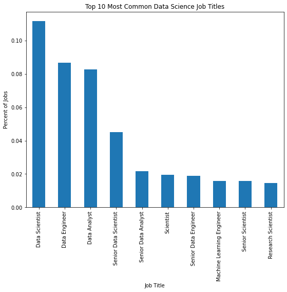

```python
ax = jobs['Job Title'].value_counts(normalize=True)[:10].plot.bar(figsize=(9, 7))
ax.set_title('Top 10 Most Common Data Science Job Titles')
ax.set_xlabel("Job Title")
ax.set_ylabel("Percent of Jobs")
```

### Salaries by Job Title

Let's see if there's any difference in estimated salary across the top 10 job titles.

```python
# get only rows where job title is in top 10
top_ten_titles = list(jobs['Job Title'].value_counts()[:10].to_dict().keys())
top_ten_jobs = jobs[jobs['Job Title'].isin(top_ten_titles)]
top_ten_jobs = top_ten_jobs[['Job Title', 'Avg Salary Estimate']]

# get median, min, and max salary per job title
top_ten_jobs_salaries = top_ten_jobs.groupby('Job Title').min()
top_ten_jobs_salaries = top_ten_jobs_salaries.rename({'Avg Salary Estimate': 'Min'}, axis=1)
top_ten_jobs_salaries['Median'] = top_ten_jobs.groupby('Job Title').median()['Avg Salary Estimate'].values
top_ten_jobs_salaries['Max'] = top_ten_jobs.groupby('Job Title').max()['Avg Salary Estimate'].values
```

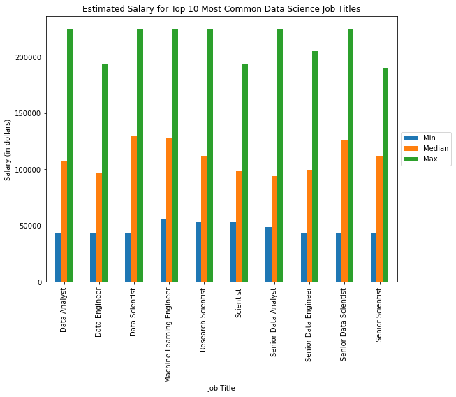

```python
ax = top_ten_jobs_salaries.plot.bar(figsize=(9, 7))
ax.set_title('Estimated Salary for Top 10 Most Common Data Science Job Titles')
ax.set_xlabel('Job Title')
ax.set_ylabel('Salary (in dollars)')
ax.legend(loc='center left', bbox_to_anchor=(1, 0.5))
```

From this graph, we can see a few key differences between the estimated salary across job titles.

- **Scientists and Senior Scientists**, while having similar median and minimum salaries as the other job titles, seem to have much lower maximum estimates.
- **Data Scientists and Senior Data Scientists**, however, seem to have higher median and maximum salary estimates than Data Analysts and Data Egnineers (and their respective Senior positions).
- **Data Engineers and Senior Data Engineers** have comparable minimum salaries as Data Analysts and Data Scientists, but have lower median and maximum salary estimates.
- **Machine Learning Engineers** have the highest minimum salary estimate, and the median and maximum salary estimates are also on the higher end.

The difference between the salary estimates of Data Analysts, Data Engineers, and Data Scientists compared to their corresponding senior positions is not as expected. Many of the estimates are the same, or the Senior position actually has a lower salary estimate. This is likely because some of the job positions that don't specify seniority are actually intended for senior/principal positions, but is not described in the job title.

### Jobs by Sector

We can see the relative frequency of jobs across the sectors here:

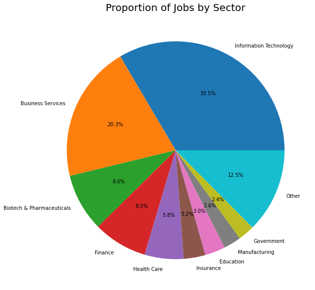

```python
# combine all but the first 9 sectors into "other" category
sectors = jobs['Sector'].value_counts(normalize=True)[:9]
sectors['Other'] = sum(jobs['Sector'].value_counts(normalize=True)[9:].values)

plt.figure(figsize=(20,10))
plt.title('Proportion of Jobs by Sector', fontsize=20)
plt.pie(sectors, labels=sectors.index, autopct='%1.1f%%')
plt.show()
```

The **Other** category includes the following sectors:

```python
jobs['Sector'].value_counts(normalize=True)[9:]
```

```
Media                                 0.022448
Retail                                0.021550
Accounting & Legal                    0.021251
Aerospace & Defense                   0.010775
Oil, Gas, Energy & Utilities          0.010177
Telecommunications                    0.006286
Consumer Services                     0.005986
Non-Profit                            0.005388
Transportation & Logistics            0.004789
Construction, Repair & Maintenance    0.004490
Real Estate                           0.003592
Arts, Entertainment & Recreation      0.002993
Restaurants, Bars & Food Services     0.002694
Agriculture & Forestry                0.001497
Travel & Tourism                      0.001197
Mining & Metals                       0.000299
Name: Sector, dtype: float64
```

### Estimated Job Salary by Sector

```python
sectors = jobs[['Sector', 'Avg Salary Estimate']]
sectors_salaries = sectors.groupby('Sector').min()
sectors_salaries = sectors_salaries.rename({'Avg Salary Estimate': 'Min'}, axis=1)
sectors_salaries['Median'] = sectors.groupby('Sector').median()
sectors_salaries['Max'] = sectors.groupby('Sector').max()
```

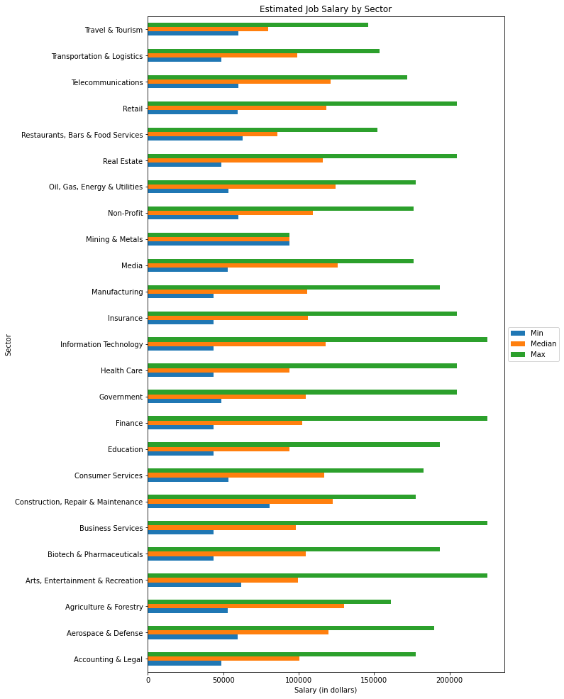

```python
ax = sectors_salaries.plot.barh(title='Estimated Job Salary by Sector', figsize=(9,17))
ax.set_ylabel('Sector')
ax.set_xlabel('Salary (in dollars)')
ax.legend(loc='center left', bbox_to_anchor=(1, 0.5))
```

From the chart above, we see that **Agriculture and Forestry** sector has the highest median salary, but doesn't have a very high maximum salary. The sectors with the highest maximum salaries are **Information Technology**, **Finance**, **Business Services**, and **Arts, Entertainment & Recreation**. However, these sectors also have some of the lowest minimum salaries, with the exception of Arts, Entertainment & Recreation.

The minimum, median, and maximum values are all the same for **Mining & Metals** because there is only one entry for that sector.

### Jobs by Location

```python
jobs['State'] = jobs['Location'].replace('[\w\s]*, ([A-Z]{2})', '\\1', regex=True)
locations = jobs[['State', 'index']]
locations = locations.groupby('State').count()
locations = locations.reset_index()
```

```python
m = folium.Map(location=[38, -99], zoom_start=4.25)

url = ("https://raw.githubusercontent.com/python-visualization/folium/master/examples/data")
state_geo = f"{url}/us-states.json"

folium.Choropleth(
    geo_data=state_geo,
    name="choropleth",
    data=locations,
    columns=['State', 'index'],
    key_on='feature.id',
    fill_color="YlGn",
    fill_opacity=0.7,
    line_opacity=0.2,
    legend_name="Number of Jobs",
).add_to(m)

folium.LayerControl().add_to(m)
m
```

Make this Notebook Trusted to load map: File -> Trust Notebook

[interactive chart not shown]

Here, we see that the vast majority of the job listings are for positions located in **California** and **Texas**, each with 1,034+ job listings. We also see that the job listings tend to be in states that are not completely land-locked, with the exception of Arizona.

### Estimated Salary by Location (State)

```python
locations = jobs[['State', 'Avg Salary Estimate']]
locations_salaries = locations.groupby('State').min()
locations_salaries = locations_salaries.rename({'Avg Salary Estimate': 'Min'}, axis=1)
locations_salaries['Median'] = locations.groupby('State').median()['Avg Salary Estimate'].values
locations_salaries['Max'] = locations.groupby('State').max()['Avg Salary Estimate'].values
```

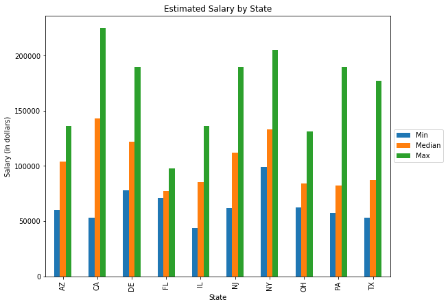

```python
ax = locations_salaries.plot.bar(figsize=(9,7))
ax.set_title('Estimated Salary by State')
ax.set_xlabel('State')
ax.set_ylabel('Salary (in dollars)')
ax.legend(loc='center left', bbox_to_anchor=(1, 0.5))
```

The graph above is nice but isn't very useful, since the cost of living can vary greatly by state. An example is California, which has the highest median and maximum estimated salary, but is also notorious for its incredibly high cost of living. Without accounting for cost of living, we can't show for sure which states offer the highest salaries.

I used cost of living indexes for 2021, taken from here: https://meric.mo.gov/data/cost-living-data-series. The cost indexes are normalized by the average cost of living across the U.S., which has a value of 100. Values greater than 100 indicate higher than average costs of living, while values less than 100 indicate lower than average costs of living. Since we only have data for a few states (10), I just entered the cost of living indexes manually into a list. If we had salary data for all 50 states, it would probably be more efficient to scrape the indexes from the website.

I normalize the salaries by dividing the median salary per state by the state's corresponding cost index.

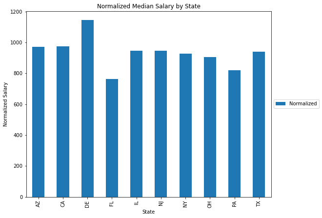

```python
locations_salaries['Cost Index'] = [107.0, 146.9, 106.6, 101.5, 90.5, 118.3, 143.7, 92.9, 100.5, 92.6]

# normalize salaries
locations_salaries['Normalized'] = locations_salaries['Median'] / locations_salaries['Cost Index']

ax = locations_salaries['Normalized'].plot.bar(figsize=(9, 7))
ax.set_title('Normalized Median Salary by State')
ax.set_xlabel('State')
ax.set_ylabel('Normalized Salary')
ax.legend(loc='center left', bbox_to_anchor=(1, 0.5))
```

## 3.2 Companies

In this section, we'll look at:

- Companies with Most Data Science Job Listings (salaries, ratings)
- Type of Ownership (vs ratings, median salaries)
- Company Size (vs ratings, median salaries)
- Company Ratings (across sectors, vs median salaries)
- Best Companies by Salary and Rating

### Top 10 Companies with Most Data Science Job Listings

Here, we can see the number of job listings per company for the top 10 companies with the most job listings:

```python
jobs['Company Name'].value_counts()[:10]
```

```
Apple                               60
IBM                                 57
Amazon                              47
Staffigo Technical Services, LLC    28
Facebook                            25
Diverse Lynx                        25
Solekai Systems Corp                24
Southwest Research Institute        23
Humana                              19
CyberCoders                         18
Name: Company Name, dtype: int64
```

```python
(sum(jobs['Company Name'].value_counts()[:10].values) / len(jobs)) * 100
```

```
8.393408856848609
```

These 10 companies make up 8.4% of all the data science job listings.

```python
top_ten_comps = list(jobs['Company Name'].value_counts()[:10].to_dict().keys())
top_ten_comps_jobs = jobs[jobs['Company Name'].isin(top_ten_comps)]
top_ten_comps_jobs[['Company Name', 'Rating', 'Sector', 'Type of ownership', 'Headquarters', 'Size']].drop_duplicates().set_index('Company Name')
```

| Company Name | Rating | Sector | Type of ownership | Headquarters | Size |
| --- | --- | --- | --- | --- | --- |
| Facebook | 4.5 | Information Technology | Company - Public | Menlo Park, CA | 10000+ employees |
| Amazon | 3.9 | Information Technology | Company - Public | Seattle, WA | 10000+ employees |
| Solekai Systems Corp | 4.2 | Information Technology | Company - Private | San Diego, CA | 1 to 50 employees |
| CyberCoders | 4.2 | Business Services | Subsidiary or Business Segment | Irvine, CA | 201 to 500 employees |
| IBM | 3.7 | Information Technology | Company - Public | Armonk, NY | 10000+ employees |
| Humana | 3.6 | Insurance | Company - Public | Louisville, KY | 10000+ employees |
| Apple | 4.1 | Information Technology | Company - Public | Cupertino, CA | 10000+ employees |
| Staffigo Technical Services, LLC | 5.0 | Information Technology | Company - Private | Woodridge, IL | 51 to 200 employees |
| Diverse Lynx | 3.9 | Information Technology | Company - Private | Princeton, NJ | 501 to 1000 employees |
| Southwest Research Institute | 4.1 | Business Services | Nonprofit Organization | San Antonio, TX | 1001 to 5000 employees |

```python
top_ten_comps_jobs = top_ten_comps_jobs[['Company Name', 'Avg Salary Estimate']]

# get median, min, and max salary per company
top_ten_comps_salaries = top_ten_comps_jobs.groupby('Company Name').min()
top_ten_comps_salaries = top_ten_comps_salaries.rename({'Avg Salary Estimate': 'Min'}, axis=1)
top_ten_comps_salaries['Median'] = top_ten_comps_jobs.groupby('Company Name').median()['Avg Salary Estimate'].values
top_ten_comps_salaries['Max'] = top_ten_comps_jobs.groupby('Company Name').max()['Avg Salary Estimate'].values
```

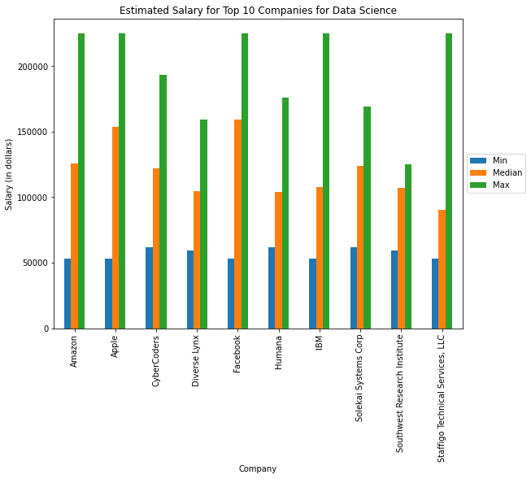

```python
ax = top_ten_comps_salaries.plot.bar(figsize=(9, 7))
ax.set_title('Estimated Salary for Top 10 Companies for Data Science')
ax.set_xlabel('Company')
ax.set_ylabel('Salary (in dollars)')
ax.legend(loc='center left', bbox_to_anchor=(1, 0.5))
```

From the chart above, we see that

- **Facebook** has the highest median estimated salary
- **Staffigo Technical Services** has the lowest median estimated salary (but one of the highest maximum salaries!)
- **Southwest Research Institute** has the lowest maximum estimated salary, which may be related to the fact that it is a non-profit.
- There is not a huge difference in minimum estimated salary across these companies.

However, there is a possibility that these salary estimates are skewed due to the types of job listings the companies had up when the data was scraped. If a company has a lot of entry-level job positions in the data, their average salary would likely be lower than a company that have more senior or principal job positions. This is true for all the salary analyses we will do later, but is especially true when grouping by company (since the number of entries per group is small).

### Type of Ownership

```python
ownership = jobs[['Company Name', 'Type of ownership']].drop_duplicates()
ownership_count = ownership.groupby('Type of ownership').count()
ownership_count = ownership_count.rename({'Company Name': 'Count'}, axis=1)
ownership_count = ownership_count.sort_values('Count', ascending=False)
ownership_count = ownership_count['Count']
ownership_count
```

```
Type of ownership
Company - Private                 1150
Company - Public                   427
Nonprofit Organization              86
Subsidiary or Business Segment      85
Government                          40
Unknown                             28
College / University                26
Contract                            12
Hospital                            10
Private Practice / Firm             10
Other Organization                   5
Self-employed                        4
School / School District             3
Franchise                            1
Name: Count, dtype: int64
```

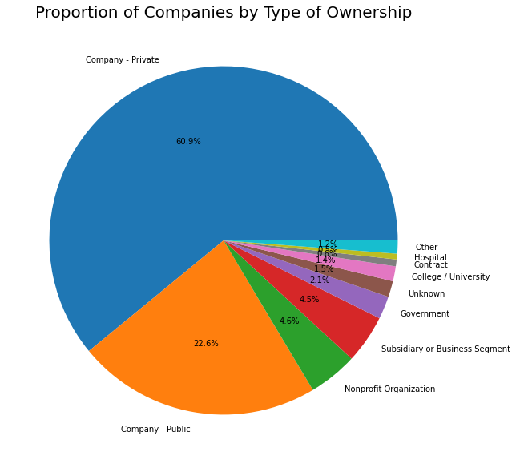

```python
# combine all but the first 9 ownership types into "other" category
other_count = sum(ownership_count[9:].values)
ownership_count_simp = ownership_count[:9]
ownership_count_simp['Other'] = other_count

plt.figure(figsize=(20,10))
plt.title('Proportion of Companies by Type of Ownership', fontsize=20)
plt.pie(ownership_count_simp, labels=ownership_count_simp.index, autopct='%1.1f%%')
plt.show()
```

The **Other** category includes:

```python
ownership_count[9:] / sum(ownership_count)
```

```
Type of ownership
Private Practice / Firm     0.005299
Other Organization          0.002650
Self-employed               0.002120
School / School District    0.001590
Franchise                   0.000530
Name: Count, dtype: float64
```

#### Estimated Salary by Ownership Type

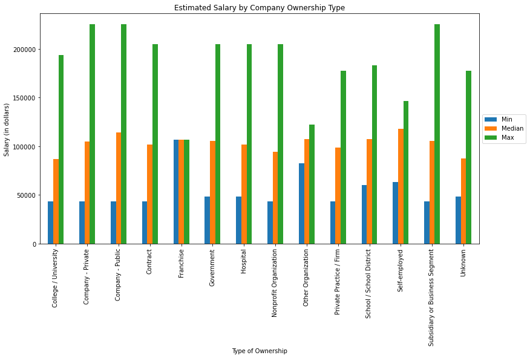

```python
ownership = jobs[['Type of ownership', 'Avg Salary Estimate']]
ownership_salaries = ownership.groupby('Type of ownership').min()
ownership_salaries = ownership_salaries.rename({'Avg Salary Estimate': 'Min'}, axis=1)
ownership_salaries['Median'] = ownership.groupby('Type of ownership').median()['Avg Salary Estimate'].values
ownership_salaries['Max'] = ownership.groupby('Type of ownership').max()['Avg Salary Estimate'].values


ax = ownership_salaries.plot.bar(figsize=(13,7))
ax.set_title('Estimated Salary by Company Ownership Type')
ax.set_xlabel('Type of Ownership')
ax.set_ylabel('Salary (in dollars)')
ax.legend(loc='center left', bbox_to_anchor=(1, 0.5))
```

From the chart above, we see that:

- **Self Employed** companies have the highest median estimated salary, but have one of the lowest maximum estimated salaries. However, there are very few data entries for self-employed companies, which makes these estimates unreliable.
- **College / University** companies have the lowest median estiamted salary, even lower than **School / School District** companies (but this category also has very few data points, so the estimates may be unreliable).
- Companies categorized as **Other Organization** have the highest minimum estimated salary (and the lowest maximum estimated salary). (This category also has very few data points, meaning these estimates are unreliable).
- **Private and public companies** and **Business Subsidary/Segments** have the highest maximum estimated salaries.

I did not include the **Franchise** category in my above analysis because there was only one entry for it.

#### Company Rating by Ownership Type

```python
ratings = jobs[['Company Name', 'Type of ownership', 'Rating']].drop_duplicates()
ratings = ratings.groupby('Type of ownership').mean()
ratings
```

| Type of ownership | Rating |
| --- | --- |
| College / University | 3.992308 |
| Company - Private | 3.816415 |
| Company - Public | 3.586967 |
| Contract | 3.750000 |
| Franchise | 3.900000 |
| Government | 3.542500 |
| Hospital | 3.760000 |
| Nonprofit Organization | 3.585542 |
| Other Organization | 2.750000 |
| Private Practice / Firm | 3.844444 |
| School / School District | 3.500000 |
| Self-employed | 3.600000 |
| Subsidiary or Business Segment | 3.541176 |
| Unknown | 3.883333 |

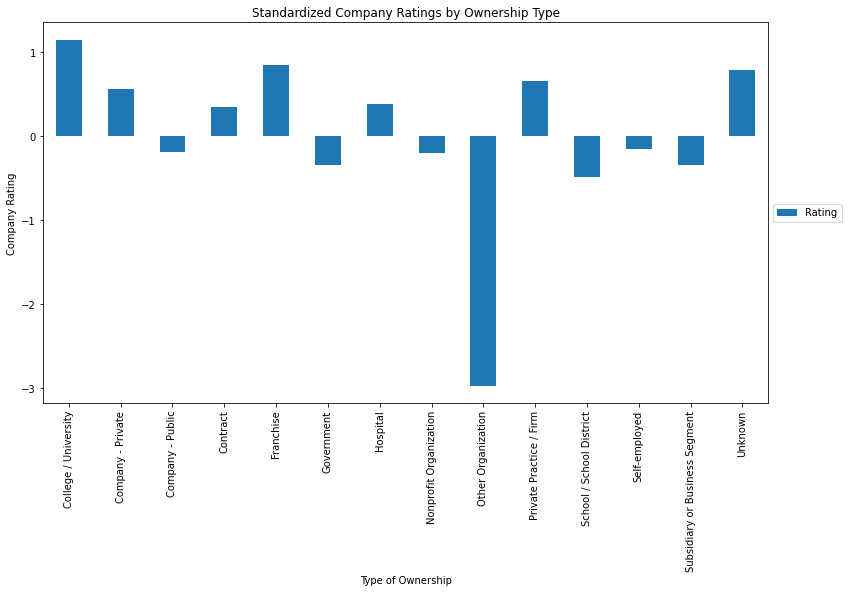

```python
# normalize ratings with z scores
ratings['Rating'] = (ratings['Rating'] - ratings['Rating'].mean()) / ratings['Rating'].std()
ax = ratings.plot.bar(figsize=(13,7))
ax.set_title('Standardized Company Ratings by Ownership Type')
ax.set_xlabel('Type of Ownership')
ax.set_ylabel('Company Rating')
ax.legend(loc='center left', bbox_to_anchor=(1, 0.5))
```

### Company Size

```python
sizes = jobs[['Company Name', 'Size']].drop_duplicates()
sizes_count = sizes.groupby('Size').count()
sizes_count = sizes_count.rename({'Company Name': 'Count'}, axis=1)
new_index = ['1 to 50 employees', '51 to 200 employees', '201 to 500 employees', '501 to 1000 employees', \
            '1001 to 5000 employees', '5001 to 10000 employees', '10000+ employees', 'Unknown']
sizes_count = sizes_count.reindex(new_index)
sizes_count = sizes_count['Count']
sizes_count
```

```
Size
1 to 50 employees          374
51 to 200 employees        350
201 to 500 employees       229
501 to 1000 employees      170
1001 to 5000 employees     301
5001 to 10000 employees    116
10000+ employees           292
Unknown                     58
Name: Count, dtype: int64
```

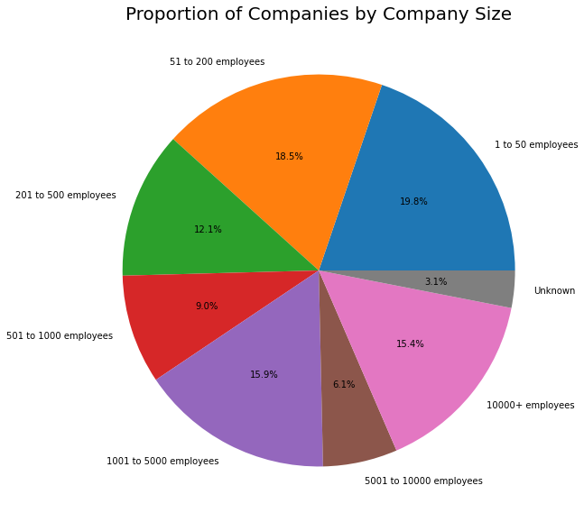

```python
plt.figure(figsize=(20,10))
plt.title('Proportion of Companies by Company Size', fontsize=20)
plt.pie(sizes_count, labels=sizes_count.index, autopct='%1.1f%%')
plt.show()
```

From the chart above, we can see that companies with **1-500** employees make up more than 50% of all the companies in the data.

#### Estimated Salary by Company Size

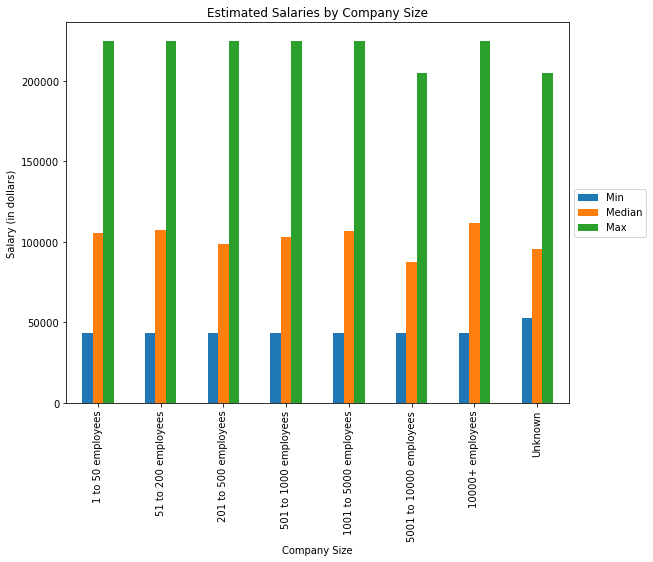

```python
size = jobs[['Size', 'Avg Salary Estimate']]
size_salaries = size.groupby('Size').min()
size_salaries = size_salaries.rename({'Avg Salary Estimate': 'Min'}, axis=1)
size_salaries['Median'] = size.groupby('Size').median()['Avg Salary Estimate'].values
size_salaries['Max'] = size.groupby('Size').max()['Avg Salary Estimate'].values
size_salaries = size_salaries.reindex(new_index)

ax = size_salaries.plot.bar(figsize=(9,7))
ax.set_title('Estimated Salaries by Company Size')
ax.set_xlabel('Company Size')
ax.set_ylabel('Salary (in dollars)')
ax.legend(loc='center left', bbox_to_anchor=(1, 0.5))
```

From the chart above, we can see that there is not much difference in estimated salary according to company size, with perhaps the exception of companies that are 5001 to 10000 employees in size, which has a lower median and maximum than the other categories. However, that category is also the smallest category (other than Unknown), and estimates may be less reliable.

#### Ratings by Company Size

```python
ratings = jobs[['Company Name', 'Size', 'Rating']].drop_duplicates()
ratings = ratings.groupby('Size').mean()
ratings = ratings.reindex(new_index)
ratings
```

| Size | Rating |
| --- | --- |
| 1 to 50 employees | 4.040484 |
| 51 to 200 employees | 3.900904 |
| 201 to 500 employees | 3.648673 |
| 501 to 1000 employees | 3.607647 |
| 1001 to 5000 employees | 3.529766 |
| 5001 to 10000 employees | 3.597414 |
| 10000+ employees | 3.610616 |
| Unknown | 4.072000 |

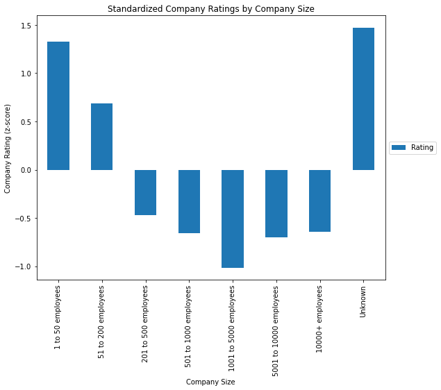

```python
# normalize ratings with z scores
ratings['Rating'] = (ratings['Rating'] - ratings['Rating'].mean()) / ratings['Rating'].std()
ax = ratings.plot.bar(figsize=(9,7))
ax.set_title('Standardized Company Ratings by Company Size')
ax.set_xlabel('Company Size')
ax.set_ylabel('Company Rating (z-score)')
ax.legend(loc='center left', bbox_to_anchor=(1, 0.5))
```

Although company size didn't seem to affect estimated salary by much, it seems there are notable differences between company ratings. Companies with **1 to 50 employees** have the highest ratings (with the exception of unknown size), while companies with **1001 to 5000 employees** have the lowest ratings.

### Company Ratings

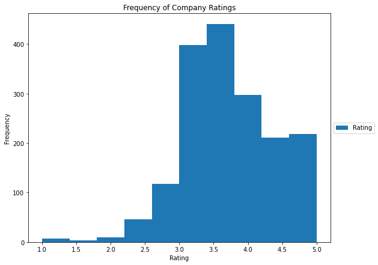

```python
ax = jobs[['Company Name', 'Rating']].drop_duplicates().plot.hist(figsize=(9,7))
ax.set_title('Frequency of Company Ratings')
ax.set_xlabel('Rating')
ax.legend(loc='center left', bbox_to_anchor=(1, 0.5))
```

Company Ratings are skewed left, with most companies having a rating of 3.0 or higher and only few companies with ratings lower than that. The most common rating is somewhere around 3.5.

#### Company Ratings by Sector

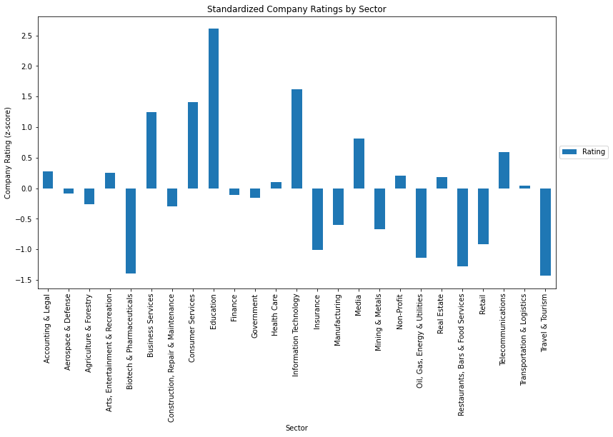

```python
ratings = jobs[['Company Name', 'Sector', 'Rating']].drop_duplicates()
sector_ratings = ratings[['Sector', 'Rating']].groupby('Sector').mean()
sector_ratings['Rating'] = (sector_ratings['Rating'] - sector_ratings['Rating'].mean()) / sector_ratings['Rating'].std()

ax = sector_ratings.plot.bar(figsize=(13,7))
ax.set_title('Standardized Company Ratings by Sector')
ax.set_xlabel('Sector')
ax.set_ylabel('Company Rating (z-score)')
ax.legend(loc='center left', bbox_to_anchor=(1, 0.5))
```

From the graph above, we can see:

- **Education** is the sector with the highest ratings. This is consistent with College/University owned companies having the highest ratings as well, which we saw previously.
- **Information Technology**, the sector with the most job listings, has the second highest ratings.
- **Travel & Tourism** and **Biotech & Pharmaceuticals** have the lowest ratings.

#### Company Ratings by Salary

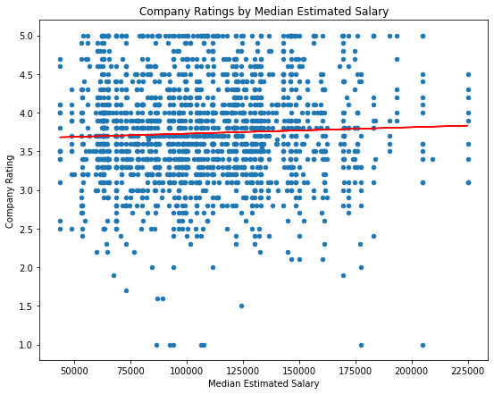

```python
ratings = jobs[['Company Name', 'Avg Salary Estimate', 'Rating']].groupby('Company Name').median()
ratings = ratings.dropna()
x = ratings['Avg Salary Estimate']
X = [[n] for n in x]
y = ratings['Rating']

# train regression model and get coefficient/intercepts
reg = LinearRegression().fit(X, y)
m = reg.coef_[0]
b = reg.intercept_

# plot salaries, ratings, and regression line
fig, ax = plt.subplots()
ratings.plot.scatter(x='Avg Salary Estimate', y='Rating', figsize=(9,7), ax=ax)
ax.set_title('Company Ratings by Median Estimated Salary')
ax.set_xlabel('Median Estimated Salary')
ax.set_ylabel('Company Rating')
plt.plot(x, m*x+b, color='red')
```

From the scatterplot and regression line above, we can see that median estimated salary doesn't seem to particularly affect company ratings. To make sure, we calculate the R^2 value and get a value of 0.002, which tells us that only 0.2% of the change in company rating can be explained by median salary at a company.

```python
y_true = y
y_pred = [reg.predict([x])[0] for x in X]
r2_score(y_true, y_pred)
```

```
0.0020009966933283163
```

### Best Companies by Salary and Rating

I wanted to find the best companies overall by taking into account both salary and rating. To do this, I first normalize both median salary and average ratings by company. I then combine the normalized salary and ratings into a company "score" by taking the mean of the two normalized values. This way, both salary and company rating are equally important; if you think one is more important than the other, you can weight the score accordingly (and may get different top companies!)

```python
# get median salary by company
companies = jobs[['Company Name', 'Avg Salary Estimate', 'Rating']]
salaries = companies[['Company Name', 'Avg Salary Estimate']].groupby('Company Name').median()

# join median salary and ratings on company name
ratings = companies[['Company Name', 'Rating']].drop_duplicates()
companies = ratings.set_index('Company Name').join(salaries, how='inner')

# normalize salary and ratings
companies = companies.rename({'Avg Salary Estimate': 'Median Salary'}, axis=1)
companies['Rating Norms'] = (companies['Rating'] - companies['Rating'].mean()) / companies['Rating'].std()
companies['Median Salary Norms'] = (companies['Median Salary'] - companies['Median Salary'].mean()) / companies['Median Salary'].std()

# score company by the mean of salary and rating z scores
companies['Score'] = (companies['Rating Norms'] + companies['Median Salary Norms']) / 2

companies = companies.sort_values('Score', ascending=False)
companies[:10].join(jobs[['Company Name', 'Sector', 'Type of ownership', 'Headquarters', 'Size']].drop_duplicates().set_index('Company Name'), how='inner')
```

| Company Name | Rating | Median Salary | Rating Norms | Median Salary Norms | Score | Sector | Type of ownership | Headquarters | Size |
| --- | --- | --- | --- | --- | --- | --- | --- | --- | --- |
| Aisera | 4.5 | 225000.0 | 1.151664 | 3.274292 | 2.212978 | Information Technology | Company - Private | Palo Alto, CA | 51 to 200 employees |
| Carbon3D | 4.3 | 225000.0 | 0.851178 | 3.274292 | 2.062735 | Information Technology | Company - Private | Redwood City, CA | 201 to 500 employees |
| Galileo | 5.0 | 205000.0 | 1.902881 | 2.717902 | 2.310391 | Health Care | Company - Private | New York, NY | 1 to 50 employees |
| HealthVerity | 5.0 | 190000.0 | 1.902881 | 2.300609 | 2.101745 | Information Technology | Company - Private | Philadelphia, PA | 51 to 200 employees |
| Indrasol | 5.0 | 183000.0 | 1.902881 | 2.105873 | 2.004377 | NaN | Subsidiary or Business Segment | Fremont, CA | 1 to 50 employees |
| Landis | 5.0 | 205000.0 | 1.902881 | 2.717902 | 2.310391 | NaN | Company - Private | New York, NY | 1 to 50 employees |
| Lily AI | 5.0 | 183000.0 | 1.902881 | 2.105873 | 2.004377 | Information Technology | Company - Private | Mountain View, CA | 1 to 50 employees |
| Moveworks | 5.0 | 183000.0 | 1.902881 | 2.105873 | 2.004377 | Information Technology | Company - Private | Mountain View, CA | 51 to 200 employees |
| Scopus IT | 4.2 | 225000.0 | 0.700935 | 3.274292 | 1.987614 | Information Technology | Company - Private | New York, NY | 1 to 50 employees |
| twoXAR | 5.0 | 193500.0 | 1.902881 | 2.397978 | 2.150429 | NaN | Company - Private | Palo Alto, CA | 1 to 50 employees |

Here, we see some common factos between the highest scoring companies:

- All but one (Indrasol; Business Segment) of the top companies (by rating and salary) are priviate companies.
- The majority of them are also in the Information Technology sector.
- All but one (HealthVerity; Pennsylvania) have headquarters in California or New York.
- All but one (Carbon3D; 201-500 employees) have 1-200 employees.

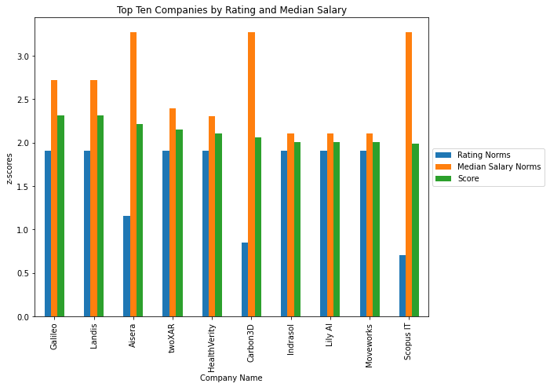

```python
ax = companies[['Rating Norms', 'Median Salary Norms', 'Score']][:10].plot.bar(figsize=(9,7))
ax.set_title('Top Ten Companies by Rating and Median Salary')
ax.set_ylabel('z-scores')
ax.legend(loc='center left', bbox_to_anchor=(1, 0.5))
```

Interestingly, the companies with the highest median salaries also have the lowest ratings.

None of the Top 10 companies by number of job listings made it into the top scored companies. Let's take a look at their scores:

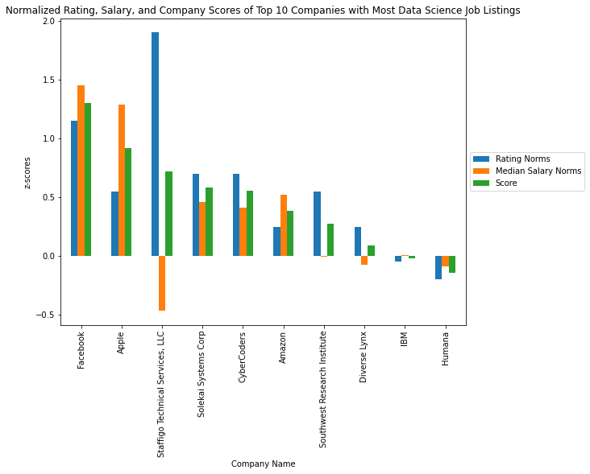

```python
companies = companies.reset_index()
top_ten = companies[companies['Company Name'].isin(top_ten_comps)]
top_ten = top_ten.set_index('Company Name')

ax = top_ten[['Rating Norms', 'Median Salary Norms', 'Score']].plot.bar(figsize=(9,7))
ax.set_title('Normalized Rating, Salary, and Company Scores of Top 10 Companies with Most Data Science Job Listings')
ax.set_ylabel('z-scores')
ax.legend(loc='center left', bbox_to_anchor=(1, 0.5))
```

Again, we see that the company with the lowest median salary (Staffigo Technical Services) also has the highest company rating.

## 3.3 Sectors

### Best Sectors by Salary and Company Ratings

Like earlier with the companies, I wanted to find the best sectors by salary and ratings. I used the same methods as before, normalizing median salary and average ratings across the sectors before averaging the z-scores to get a sector score.

```python
# get mean salary by sector
salaries = jobs[['Sector', 'Avg Salary Estimate']].groupby('Sector').median()

# drop duplicate occurrences of companies and get mean company rating by sector
ratings = jobs[['Company Name', 'Sector', 'Rating']].drop_duplicates()
ratings = ratings[['Sector', 'Rating']].groupby('Sector').mean()
sectors = ratings.join(salaries, how='inner')

# normalize salaries and ratings
sectors = sectors.rename({'Avg Salary Estimate': 'Median Salary'}, axis=1)
sectors['Median Salary Norms'] = (sectors['Median Salary'] - sectors['Median Salary'].mean()) / sectors['Median Salary'].std()
sectors['Rating Norms'] = (sectors['Rating'] - sectors['Rating'].mean()) / sectors['Rating'].std()

# score sector by mean of salaries and ratings
sectors['Score'] = (sectors['Median Salary Norms'] + sectors['Rating Norms']) / 2

sectors = sectors.sort_values('Score', ascending=False)
sectors
```

| Sector | Rating | Median Salary | Median Salary Norms | Rating Norms | Score |
| --- | --- | --- | --- | --- | --- |
| Information Technology | 3.874950 | 118000.0 | 0.785811 | 1.622998 | 1.204405 |
| Media | 3.741860 | 126000.0 | 1.391446 | 0.809422 | 1.100434 |
| Consumer Services | 3.840000 | 117000.0 | 0.710107 | 1.409349 | 1.059728 |
| Telecommunications | 3.707143 | 121000.0 | 1.012924 | 0.597193 | 0.805059 |
| Education | 4.036364 | 94000.0 | -1.031094 | 2.609721 | 0.789314 |
| Agriculture & Forestry | 3.566667 | 130000.0 | 1.694264 | -0.261539 | 0.716363 |
| Aerospace & Defense | 3.595455 | 119750.0 | 0.918294 | -0.085558 | 0.416368 |
| Construction, Repair & Maintenance | 3.560000 | 122500.0 | 1.126481 | -0.302292 | 0.412094 |
| Real Estate | 3.640000 | 115750.0 | 0.615477 | 0.186748 | 0.401112 |
| Business Services | 3.812536 | 98000.0 | -0.728276 | 1.241459 | 0.256592 |
| Non-Profit | 3.642857 | 109500.0 | 0.142324 | 0.204214 | 0.173269 |
| Oil, Gas, Energy & Utilities | 3.424000 | 124500.0 | 1.277890 | -1.133661 | 0.072115 |
| Retail | 3.460465 | 118500.0 | 0.823664 | -0.910749 | -0.043543 |
| Accounting & Legal | 3.655556 | 100500.0 | -0.539015 | 0.281839 | -0.128588 |
| Arts, Entertainment & Recreation | 3.650000 | 99500.0 | -0.614719 | 0.247878 | -0.183421 |
| Government | 3.583784 | 104500.0 | -0.236198 | -0.156902 | -0.196550 |
| Finance | 3.591603 | 102500.0 | -0.387606 | -0.109103 | -0.248354 |
| Transportation & Logistics | 3.616667 | 99250.0 | -0.633646 | 0.044111 | -0.294767 |
| Manufacturing | 3.510938 | 105500.0 | -0.160493 | -0.602211 | -0.381352 |
| Health Care | 3.625000 | 94000.0 | -1.031094 | 0.095053 | -0.468020 |
| Insurance | 3.443902 | 106000.0 | -0.122641 | -1.011997 | -0.567319 |
| Biotech & Pharmaceuticals | 3.381522 | 104500.0 | -0.236198 | -1.393331 | -0.814764 |
| Mining & Metals | 3.500000 | 94000.0 | -1.031094 | -0.669072 | -0.850083 |
| Restaurants, Bars & Food Services | 3.400000 | 86000.0 | -1.636728 | -1.280373 | -1.458551 |
| Travel & Tourism | 3.375000 | 79750.0 | -2.109881 | -1.433198 | -1.771539 |

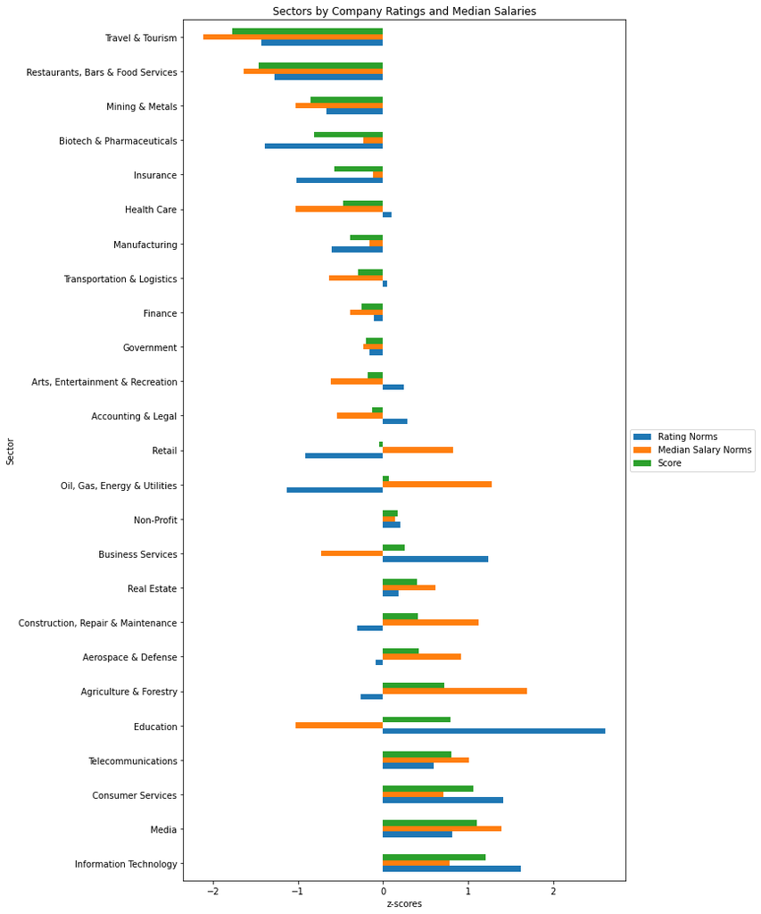

```python
ax = sectors[['Rating Norms', 'Median Salary Norms', 'Score']].plot.barh(figsize=(9,18))
ax.set_title('Sectors by Company Ratings and Median Salaries')
ax.set_xlabel('z-scores')
ax.legend(loc='center left', bbox_to_anchor=(1, 0.5))
```

# 4. Machine Learning

Now that we've taken a look at the various factors affecting job salaries and company ratings, let's see if we can train a machine learning model to predict them.

## 4.1 Salary

For training a model to predict salary, I used only the features that might have an effect on salary. Even though we saw earlier that there is little correlation between salary and company rating, I included it as an input feature anyway; the model should figure out whether there is a relationship between them.

Since many of the relevant features are categorical, I used `pd.get_dummies()` to convert categorical features into one-hot vector representations. However, because there are so many unique values for Job Title, Company Name, and Location, we end up with an input vector of length 2788.

Ideally, we would probably want to reduce the unique values in the Job Title category much further (I left quite a bit of noise in that category when I cleaned the data in section 2).

```python
jobs_ml = jobs[['Job Title',
               'Avg Salary Estimate',
               'Location',
               'Rating',
               'Company Name',
               'Size',
               'Sector',
               'Revenue']]
jobs_ml = jobs_ml.dropna()
y = jobs_ml['Avg Salary Estimate']
X = jobs_ml.drop(['Avg Salary Estimate'], axis=1)

# convert non-numerical features to one-hot vectors
X = pd.get_dummies(data=X, drop_first=True)
X.shape, y.shape
```

```
((3278, 2788), (3278,))
```

```python
# split the data into training and test sets
X_train, X_test, y_train, y_test = train_test_split(X, y, test_size = 0.2, random_state = 12)
X_train.shape, X_test.shape
```

```
((2622, 2788), (656, 2788))
```

```python
dtreg = DecisionTreeRegressor(max_depth=9)
dtreg = dtreg.fit(X_train, y_train)

train_score = dtreg.score(X_train, y_train)
test_score = dtreg.score(X_test, y_test)

print('Training Score:', train_score)
print('Test Score:', test_score)
```

```
Training Score: 0.33212465819882875
Test Score: 0.20709094739932643
```

This model is doing pretty poorly. This is likely because seniority of job position is an important predictor of salary. However, in our data, seniority can only be expressed in the job title - but as we saw earlier during our exploration of the job titles, seniority is likely not properly indicated in many job titles (which resulted in occurences such as 'Data Analyst' having a higher median salary than 'Senior Data Analyst'). Another issue is that the job title feature is too noisy; there are too many unique job titles, many of which have very few instances and very little differentiation from other job titles. Those job titles should probably be merged into one of the larger job title groups.

The model is at least doing much better than simply guessing the most common salary value (68500). However, this is not surprising because there are many unqiue salary values and the most common value accounts for only approximately 3% of the data.

```python
y.value_counts(normalize=True)
```

```
68500.0     0.027761
122000.0    0.026236
130000.0    0.024100
63000.0     0.023490
111500.0    0.022575
              ...
76500.0     0.002441
94500.0     0.002441
55000.0     0.001830
149500.0    0.000915
57500.0     0.000305
Name: Avg Salary Estimate, Length: 111, dtype: float64
```

## 4.2 Company Rating

For training a model to predict company rating, I used only the features that might have an effect on ratings. Like ebefore, I still included median company salary as an input feature. I once again converted categorical features into one-hot vectors with `pd.get_dummies()`. This time, the only features with many unique values are Company Name and Headquarters, so our input vector is shorter this time (length 1730).

```python
# simplify headquarters values
jobs['Headquarters'] = jobs['Headquarters'].replace('[\w\s]*, (\w)', '\\1', regex=True)

companies = jobs[['Company Name',
                     'Rating',
                     'Headquarters',
                     'Size',
                     'Type of ownership',
                     'Sector',
                     'Revenue']].drop_duplicates()
comp_salaries = jobs[['Company Name', 'Avg Salary Estimate']].groupby('Company Name').median()
companies_ml = companies.set_index('Company Name').join(comp_salaries, on='Company Name', how='inner')
companies_ml = companies_ml.dropna().reset_index()

y = companies_ml['Rating']
X = companies_ml.drop(['Rating'], axis=1)

# convert non-numerical features to one-hot vectors
X = pd.get_dummies(data=X, drop_first=True)
X.shape, y.shape
```

```
((1610, 1730), (1610,))
```

```python
# split the data into training and test sets
X_train, X_test, y_train, y_test = train_test_split(X, y, test_size = 0.2, random_state = 12)
X_train.shape, X_test.shape
```

```
((1288, 1730), (322, 1730))
```

```python
dtreg = DecisionTreeRegressor(max_depth=7)
dtreg = dtreg.fit(X_train, y_train)

train_score = dtreg.score(X_train, y_train)
test_score = dtreg.score(X_test, y_test)

print('Training Score:', train_score)
print('Test Score:', test_score)
```

```
Training Score: 0.246482621254682
Test Score: 0.04587145582277463
```

The rating model is also doing pretty poorly; in fact, it's doing worse than the salaries model. I thought it might be because of including the company name in the feature vector when every entry should have a unique company name (since we dropped duplicates), but the model performed even worse without it. I also tried several different maximum depths to see if the model was overfitting, but the highest test score I managed to achieve was with a max depth of 7, shown above.

```python
y.value_counts(normalize=True).head()
```

```
3.6    0.072671
3.4    0.069565
3.7    0.067702
3.9    0.065839
3.8    0.059627
Name: Rating, dtype: float64
```

# 5. Conclusion

From the data exploration and analysis, we were able to identify some key insights about the Data Science job market. Jobs labeled as "Data Scientists" seem to have a higher median salary than "Data Analysts" or "Data Engineers". Jobs labeled as just "Scientist" have comparable median salaries but much lower maximum salaries. The majority of data science jobs are in the Information Technology and Business sectors, and are located in California and Texas. However, working in Delaware is likely to give the highest salary compared to living costs.

However, we were not able to create a good model for predicting job salary or company ratings. This may be because the data is simply not easily separable. Another factor that may have reduced model strenght is the categorical features with a high number of unique values. Reducing the number of unique values ond making sure that values are accurate could possibly improve model accuracy. Obtaining numerical values for revenue and size instead of relying on categorical bins could also improve the model accuracy.